# Exploring data from the GESIS Panel Special Survey on the Coronavirus SARS-CoV-2 Outbreak in Germany

R User

2021-07-30

# 1 The data

The data we use comes from the [Public Use File (PUF) of the GESIS Panel Special Survey on the Coronavirus SARS-CoV-2 Outbreak in Germany](https://www.gesis.org/gesis-panel/coronavirus-outbreak/public-use-file-puf). We have selected 29 variables of interest for our analysis. The dataset includes data for *N* = 3765 respondents.

## 1.1 Missing data

As not all of the respondents answered every question in the survey, we have missing data. Before we further explore the data, we want to know whether there are identifiable patterns of missingness in them.

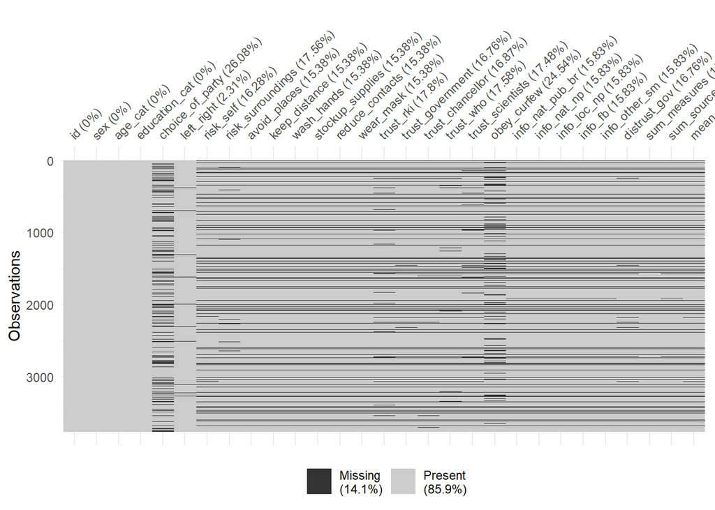

```r
library(visdat)

vis_miss(corona_survey)
```

# 2 Exploring the *GESIS Panel Special Survey on the Coronavirus SARS-CoV-2 Outbreak in Germany* dataset

## 2.1 Demographics

We first want to look at gender, age (categories), education, and party affiliation in our sample.

```r
library(janitor)

corona_survey %>%
  tabyl(sex) %>%
  adorn_totals("row") %>%
  adorn_pct_formatting() %>%
  knitr::kable()
```

| sex | n | percent |
| --- | --- | --- |
| Male | 1933 | 51.3% |
| Female | 1832 | 48.7% |
| Total | 3765 | 100.0% |

```r
corona_survey %>%
  tabyl(age_cat) %>%
  adorn_totals("row") %>%
  adorn_pct_formatting() %>%
  knitr::kable()
```

| age_cat | n | percent |
| --- | --- | --- |
| <= 25 years | 107 | 2.8% |
| 26 to 30 years | 267 | 7.1% |
| 31 to 35 years | 276 | 7.3% |
| 36 to 40 years | 328 | 8.7% |
| 41 to 45 years | 317 | 8.4% |
| 46 to 50 years | 367 | 9.7% |
| 51 to 60 years | 978 | 26.0% |
| 61 to 65 years | 386 | 10.3% |
| 66 to 70 years | 357 | 9.5% |
| >= 71 years | 382 | 10.1% |
| Total | 3765 | 100.0% |

```r
corona_survey %>%
  tabyl(education_cat) %>%
  adorn_totals("row") %>%
  adorn_pct_formatting() %>%
  knitr::kable()
```

| education_cat | n | percent |
| --- | --- | --- |
| Low | 423 | 11.2% |
| Medium | 1154 | 30.7% |
| High | 2188 | 58.1% |
| Total | 3765 | 100.0% |

```r
corona_survey %>%
  tabyl(choice_of_party) %>%
  adorn_totals("row") %>%
  adorn_pct_formatting() %>%
  knitr::kable()
```

| choice_of_party | n | percent | valid_percent |
| --- | --- | --- | --- |
| CDU/CSU | 753 | 20.0% | 27.1% |
| SPD | 369 | 9.8% | 13.3% |
| FDP | 254 | 6.7% | 9.1% |
| Linke | 287 | 7.6% | 10.3% |
| Gruene | 756 | 20.1% | 27.2% |
| AfD | 281 | 7.5% | 10.1% |
| Other | 83 | 2.2% | 3.0% |
| NA | 982 | 26.1% | - |
| Total | 3765 | 100.0% | 100.0% |

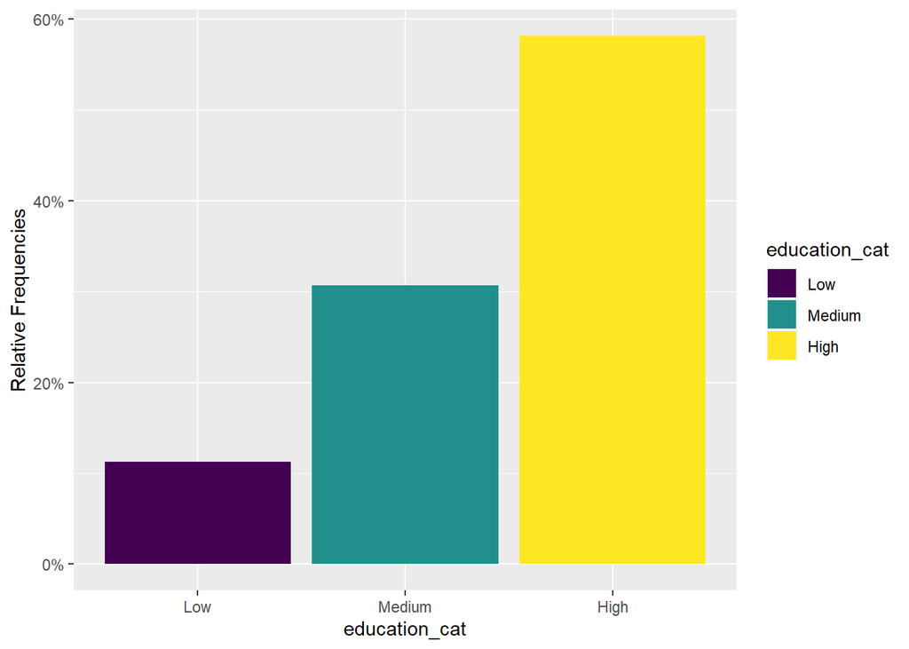

```r
corona_survey %>%
  ggplot(aes(x = education_cat,
             fill = education_cat)) +
  geom_bar(aes(y = (..count..)/sum(..count..))) +
  scale_y_continuous(labels=scales::percent) +
  ylab("Relative Frequencies")
```

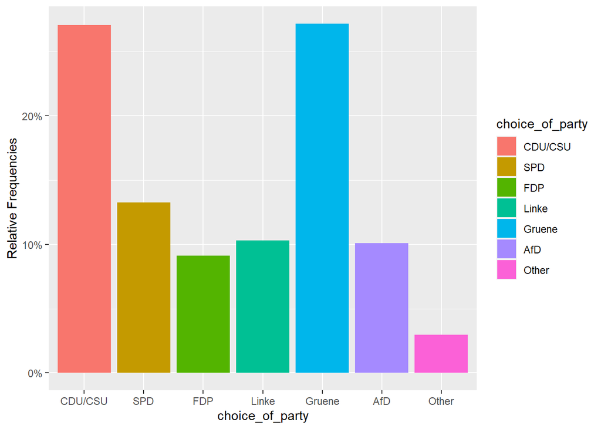

```r
corona_survey %>%
  filter(!is.na(choice_of_party)) %>%
  ggplot(aes(x = choice_of_party,
             fill = choice_of_party)) +
  geom_bar(aes(y = (..count..)/sum(..count..))) +
  scale_y_continuous(labels=scales::percent) +
  ylab("Relative Frequencies")
```

## 2.2 Summary statistics

Let’s look at the summary statistic for the items on trust in institutions.

```r
library(pander)

corona_survey %>%
  select(starts_with("trust")) %>%
  summary() %>%
  pander()
```

Table continues below

| trust_rki | trust_government | trust_chancellor | trust_who |
| --- | --- | --- | --- |
| Min. :1.000 | Min. :1.000 | Min. :1.000 | Min. :1.000 |
| 1st Qu.:4.000 | 1st Qu.:3.000 | 1st Qu.:3.000 | 1st Qu.:4.000 |
| Median :5.000 | Median :4.000 | Median :4.000 | Median :4.000 |
| Mean :4.441 | Mean :3.663 | Mean :3.573 | Mean :3.968 |
| 3rd Qu.:5.000 | 3rd Qu.:4.000 | 3rd Qu.:4.000 | 3rd Qu.:5.000 |
| Max. :5.000 | Max. :5.000 | Max. :5.000 | Max. :5.000 |
| NA’s :670 | NA’s :631 | NA’s :635 | NA’s :662 |

| trust_scientists |
| --- |
| Min. :1.000 |
| 1st Qu.:4.000 |
| Median :4.000 |
| Mean :4.239 |
| 3rd Qu.:5.000 |
| Max. :5.000 |
| NA’s :658 |

## 2.3 Distribution of variables

We want to explore how some of the data for the question on the perceived personal risk of getting infected with the Coronavirus and political orientation (left-right) are distributed in our sample.

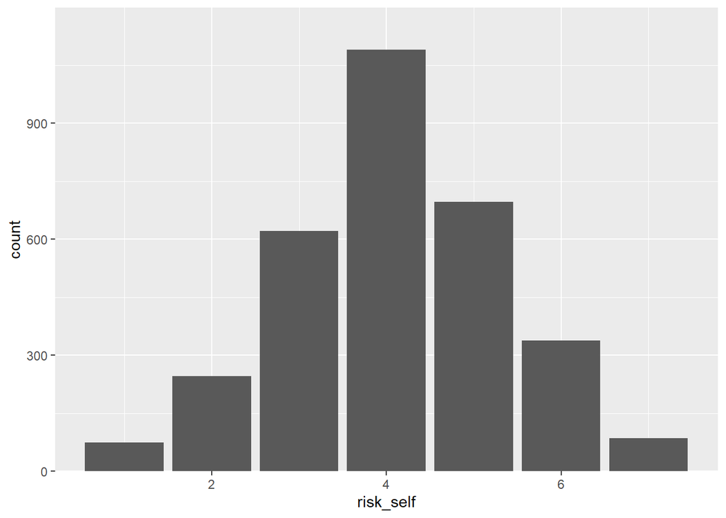

```r
corona_survey %>%
  ggplot(aes(x = risk_self)) +
  geom_bar() +
  scale_y_continuous(expand=expansion(mult=c(0,0.1)))
```

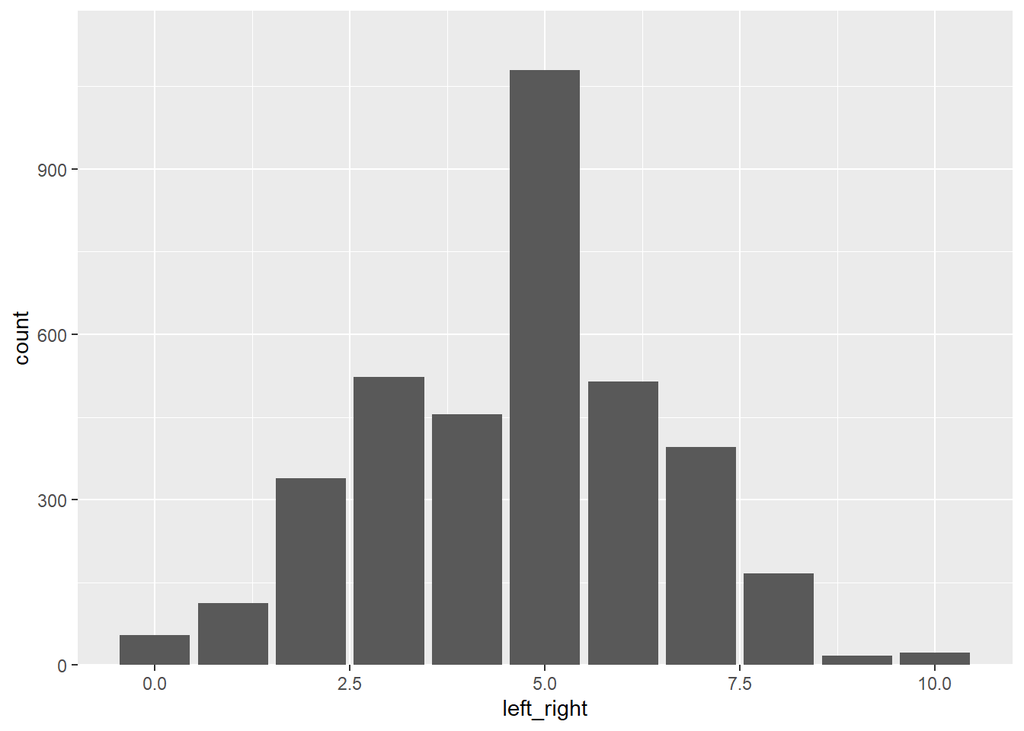

```r
corona_survey %>%
  ggplot(aes(x = left_right)) +
  geom_bar() +
  scale_y_continuous(expand=expansion(mult=c(0,0.1)))
```

## 2.4 Party affiliation and trust in government

How does trusting the government in dealing with the Coronavirus differ between supporters of different parties?

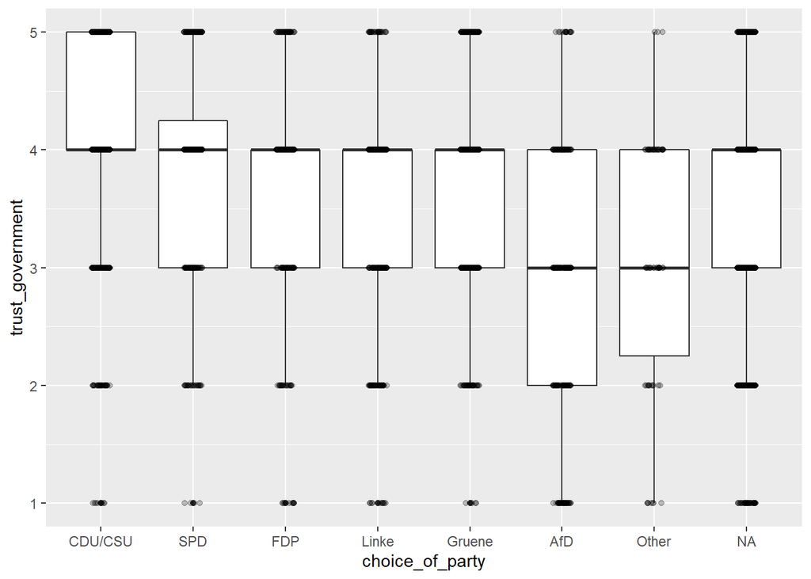

```r
corona_survey %>%
  ggplot(aes(x = choice_of_party, y = trust_government)) +
  geom_boxplot() +
  geom_jitter(position = position_jitter(width = 0.1, height = 0),
              alpha = 0.25)
```

# 3 Analyses

## 3.1 Correlations

We want to explore the correlations between political orientation, number of preventive measures taken, trust in different institutions with regard to dealing with the Coronavirus, and the sum of (a subset of) media sources people use to get current information about the Coronavirus.

```r
library(correlation)
library(GGally)

corona_survey %>%
  select(left_right,
         sum_measures,
         starts_with("trust"),
         sum_sources) %>%
  correlation %>%
  knitr::kable()
```

| Parameter1 | Parameter2 | r | CI | CI_low | CI_high | t | df_error | p | Method | n_Obs |
| --- | --- | --- | --- | --- | --- | --- | --- | --- | --- | --- |
| left_right | sum_measures | 0.0201827 | 0.95 | -0.0148296 | 0.0551456 | 1.1301021 | 3134 | 0.5170394 | Pearson correlation | 3136 |
| left_right | trust_rki | -0.0316703 | 0.95 | -0.0670984 | 0.0038376 | -1.7487790 | 3046 | 0.2412899 | Pearson correlation | 3048 |
| left_right | trust_government | -0.0650442 | 0.95 | -0.1000931 | -0.0298342 | -3.6204043 | 3085 | 0.0011955 | Pearson correlation | 3087 |
| left_right | trust_chancellor | -0.1147904 | 0.95 | -0.1494636 | -0.0798351 | -6.4182022 | 3085 | 0.0000000 | Pearson correlation | 3087 |
| left_right | trust_who | -0.1068482 | 0.95 | -0.1417624 | -0.0716684 | -5.9397208 | 3055 | 0.0000000 | Pearson correlation | 3057 |
| left_right | trust_scientists | -0.0754951 | 0.95 | -0.1106215 | -0.0401802 | -4.1881322 | 3060 | 0.0002024 | Pearson correlation | 3062 |
| left_right | sum_sources | -0.0052386 | 0.95 | -0.0403170 | 0.0298528 | -0.2925667 | 3119 | 0.7698728 | Pearson correlation | 3121 |
| sum_measures | trust_rki | 0.1629070 | 0.95 | 0.1284055 | 0.1970146 | 9.1812143 | 3092 | 0.0000000 | Pearson correlation | 3094 |
| sum_measures | trust_government | 0.1831795 | 0.95 | 0.1491174 | 0.2168073 | 10.4262870 | 3131 | 0.0000000 | Pearson correlation | 3133 |
| sum_measures | trust_chancellor | 0.1907645 | 0.95 | 0.1567715 | 0.2243060 | 10.8670352 | 3127 | 0.0000000 | Pearson correlation | 3129 |
| sum_measures | trust_who | 0.1472603 | 0.95 | 0.1126510 | 0.1815128 | 8.2894816 | 3100 | 0.0000000 | Pearson correlation | 3102 |
| sum_measures | trust_scientists | 0.1657505 | 0.95 | 0.1313457 | 0.1997565 | 9.3640763 | 3104 | 0.0000000 | Pearson correlation | 3106 |
| sum_measures | sum_sources | 0.1263081 | 0.95 | 0.0918877 | 0.1604269 | 7.1643819 | 3166 | 0.0000000 | Pearson correlation | 3168 |
| trust_rki | trust_government | 0.5233628 | 0.95 | 0.4972267 | 0.5485500 | 34.0643727 | 3076 | 0.0000000 | Pearson correlation | 3078 |
| trust_rki | trust_chancellor | 0.4566379 | 0.95 | 0.4281974 | 0.4841747 | 28.4486768 | 3072 | 0.0000000 | Pearson correlation | 3074 |
| trust_rki | trust_who | 0.5234133 | 0.95 | 0.4971789 | 0.5486915 | 33.9412856 | 3053 | 0.0000000 | Pearson correlation | 3055 |
| trust_rki | trust_scientists | 0.4919817 | 0.95 | 0.4646480 | 0.5183788 | 31.2497329 | 3058 | 0.0000000 | Pearson correlation | 3060 |
| trust_rki | sum_sources | 0.0940048 | 0.95 | 0.0589501 | 0.1288279 | 5.2487589 | 3090 | 0.0000015 | Pearson correlation | 3092 |
| trust_government | trust_chancellor | 0.8700270 | 0.95 | 0.8612220 | 0.8783098 | 98.4626898 | 3113 | 0.0000000 | Pearson correlation | 3115 |
| trust_government | trust_who | 0.5686134 | 0.95 | 0.5442444 | 0.5920236 | 38.3806688 | 3083 | 0.0000000 | Pearson correlation | 3085 |
| trust_government | trust_scientists | 0.4475961 | 0.95 | 0.4189516 | 0.4753506 | 27.8191059 | 3089 | 0.0000000 | Pearson correlation | 3091 |
| trust_government | sum_sources | 0.0691825 | 0.95 | 0.0342357 | 0.1039603 | 3.8791857 | 3129 | 0.0005348 | Pearson correlation | 3131 |
| trust_chancellor | trust_who | 0.5322833 | 0.95 | 0.5064906 | 0.5571242 | 34.8888508 | 3079 | 0.0000000 | Pearson correlation | 3081 |
| trust_chancellor | trust_scientists | 0.3899243 | 0.95 | 0.3595873 | 0.4194378 | 23.5152715 | 3084 | 0.0000000 | Pearson correlation | 3086 |
| trust_chancellor | sum_sources | 0.0727966 | 0.95 | 0.0378410 | 0.1075743 | 4.0802796 | 3125 | 0.0002766 | Pearson correlation | 3127 |
| trust_who | trust_scientists | 0.5117994 | 0.95 | 0.4851994 | 0.5374530 | 32.9867538 | 3066 | 0.0000000 | Pearson correlation | 3068 |
| trust_who | sum_sources | 0.0819061 | 0.95 | 0.0468367 | 0.1167739 | 4.5742376 | 3098 | 0.0000397 | Pearson correlation | 3100 |
| trust_scientists | sum_sources | 0.0994707 | 0.95 | 0.0645147 | 0.1341829 | 5.5676919 | 3102 | 0.0000003 | Pearson correlation | 3104 |

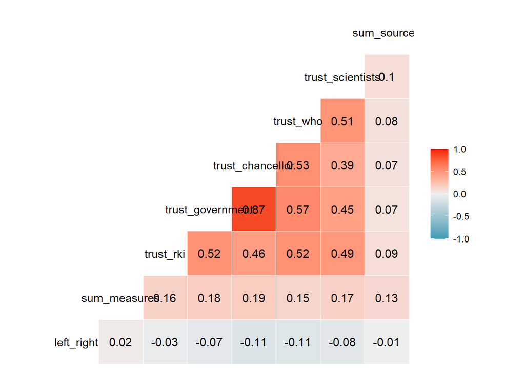

```r
corona_survey %>%
  select(left_right,
         sum_measures,
         starts_with("trust"),
         sum_sources) %>%
  ggcorr(label = TRUE,
         label_round = 2)
```

## 3.2 Regression analysis

We use a logistic regression model to explore how the willingness to obey a possible curfew (full lockdown) is predicted by mean trust in (selected) institutions and the perceived personal risk of getting infected with the Coronavirus.

```r
library(broom)

model <- glm(obey_curfew ~ 1 + mean_trust + risk_self,
             family = binomial(link = "logit"),
             data = corona_survey)

tidy_model <- model %>%
  tidy()

tidy_model %>%
  knitr::kable()
```

| term | estimate | std.error | statistic | p.value |
| --- | --- | --- | --- | --- |
| (Intercept) | -1.5025593 | 0.3481782 | -4.315489 | 0.0000159 |
| mean_trust | 0.8799896 | 0.0802846 | 10.960872 | 0.0000000 |
| risk_self | 0.1215883 | 0.0535266 | 2.271551 | 0.0231136 |

```r
glance(model)
```

| null.deviance | df.null | logLik | AIC | BIC | deviance | df.residual | nobs |
| --- | --- | --- | --- | --- | --- | --- | --- |
| 1686.944 | 2785 | -779.4587 | 1564.917 | 1582.714 | 1558.917 | 2783 | 2786 |

The unstandardized regression coefficient for the perceived personal risk of getting infected with the Coronavirus is *b* = 0.12 (p=0.023), while the coefficient for mean trust in institutions is *b* = 0.88 (p<0.001).

### 3.2.1 Regression plots

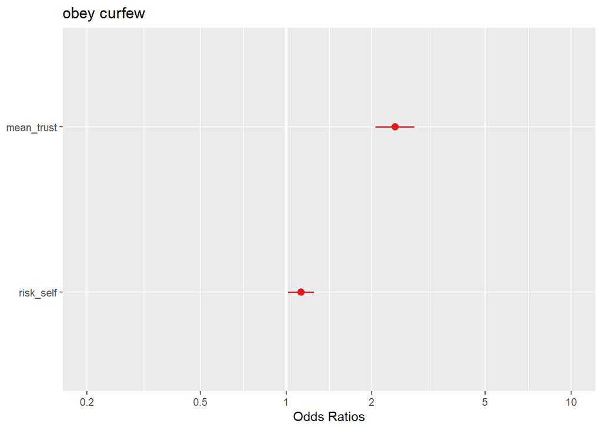

```r
library(sjPlot)

plot_model(model)
```

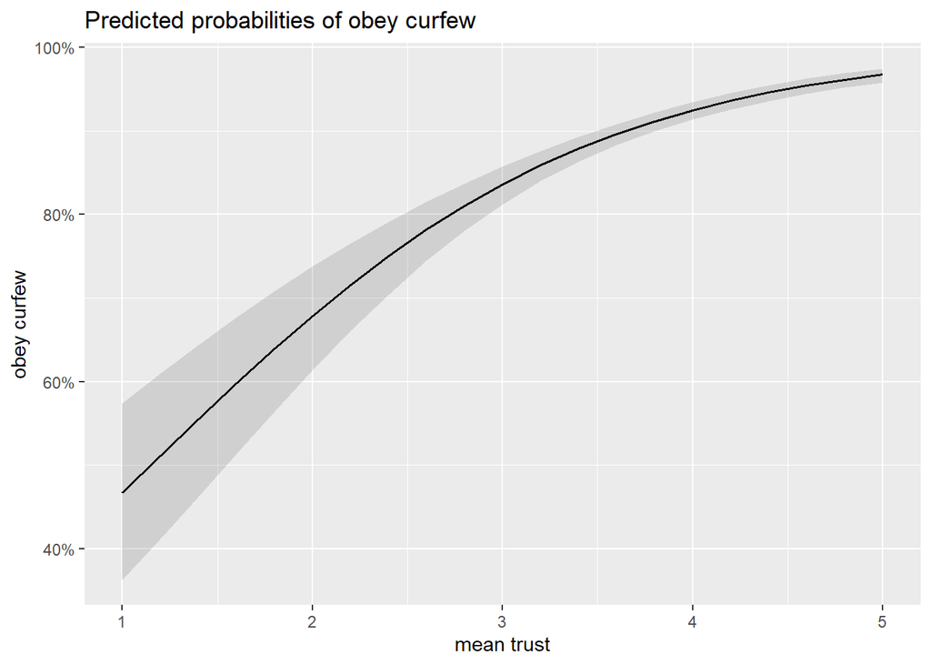

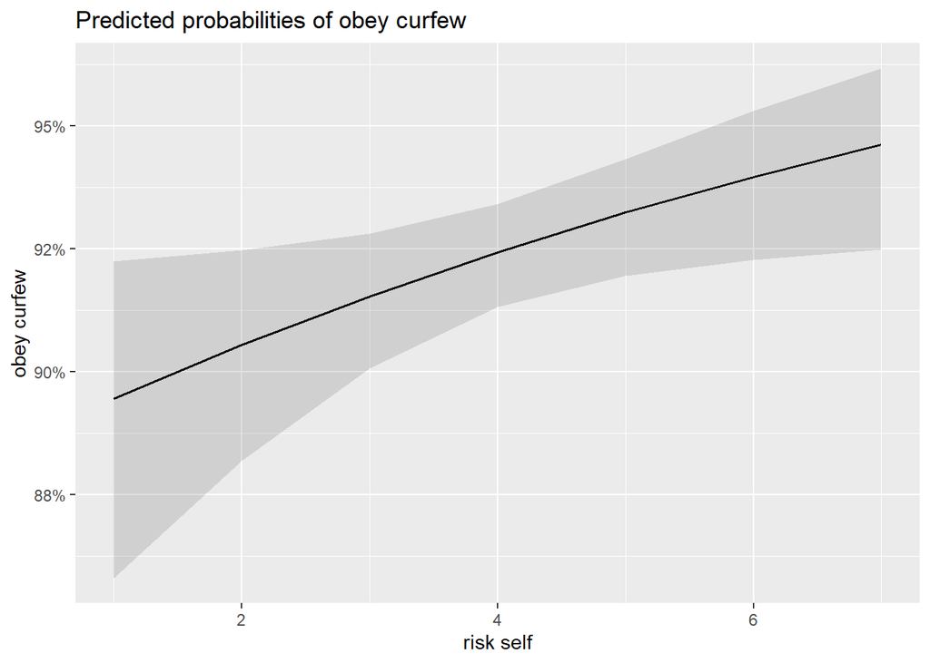

```r
plot_model(model,
           type = "pred")
```